# Project 8 DL NLP Airline Sentiment Class

### Deep Learning NLP : Natural Language Processing

### Project 8 DL NLP Airline Sentiment Classification

#### Goal: Create a Classifier Model Capable of determining Airline Customers' Sentiments as Positive, Negative, Neutral.

#### Data Description:

A sentiment analysis job about the problems of each major U.S. airline. Twitter data was scraped from February of 2015 and contributors were asked to first classify positive, negative, and neutral tweets, followed by categorizing negative reasons (such as "late flight" or "rude service").

Dataset:  
The project is from a dataset from Kaggle. Link to the Kaggle project site: https://www.kaggle.com/crowdflower/twitter-airline-sentiment. However, for this project's purpose the dataset has already been provided in a flat file "Tweets.csv", so no need to download from its original soure at Kaggle website.

##### The dataset has the following columns:

| No. | Column Names | No. | Column Names | No. | Column Names. |
| --- | --- | --- | --- | --- | --- |
| 01. | tweet_id | 06. | airline | 11. | text |
| 02. | airline_sentiment | 07. | airline_sentiment_gold | 12. | tweet_coord |
| 03. | airline_sentiment_confidence | 08. | name | 13. | tweet_created |
| 04. | negativereason | 09. | negativereason_gold | 14. | tweet_location |
| 05. | negativereason_confidence | 10. | retweet_count | 15. | user_timezone |

#### Rubric & Steps & Tasks to Follow:

Step 1. Import the libraries, load dataset, print shape of data, data description. (5 Marks)

Step 2. Understand of data-columns: (5 Marks)

- 2a. Drop all other columns except “text” and “airline_sentiment”.
- 2b. Check the shape of data.
- 2c. Print first 5 rows of data.

Step 3. Text pre-processing: Data preparation. (20 Marks)

- 3a. Html tag removal.
- 3b. Tokenization.
- 3c. Remove the numbers.
- 3d. Removal of Special Characters and Punctuations.
- 3e. Conversion to lowercase.
- 3f. Lemmatize or stemming.
- 3g. Join the words in the list to convert back to text string in the dataframe. (So that each row contains the data in text format).
- 3h. Print first 5 rows of data after pre-processing.

Step 4. Vectorization: (10 Marks)

- 4a. Use CountVectorizer.
- 4b. Use TfidfVectorizer.

Step 5. Fit and evaluate model using both type of vectorization. (6+6 Marks)

- 5a. CountVectorizer: Fit & evaluate model.
- 5b. TfidfVectorizer: Fit & evaluate model.

Step 6. Summarize your understanding of the application of Various Pre-processing and Vectorization and performance of your model on this dataset. (8 Marks)

### ⬇ Begin Code:

#### ⬇ Load Libraries :

```python
# ⬇====== Standard Libraries Begin ======⬇ #

import warnings
warnings.filterwarnings('ignore')

import spacy  # Commercial Production Grade. Tokenization, Stemming, Lemmatization, etc

import numpy as np
import pandas as pd
import seaborn as sns

import matplotlib.pyplot as plt
%matplotlib inline

import re, string, unicodedata, contractions
# Regex (re = Regular Expression) Remove Special characters. Remove Accented characters. "contractions" for ?

import nltk  # Naturalization Language Tool Kit (Academic Grade). Tokenization, Stemming, Lemmatization, etc.
from nltk.corpus import wordnet, stopwords  # For Stopwords, Wordnet corpus. # nltk.download('stopwords'). nltk.download('wordnet')
from nltk.tokenize.toktok import ToktokTokenizer
from nltk import word_tokenize, sent_tokenize, punkt  # nltk.download('punkt')
from nltk.stem import LancasterStemmer, WordNetLemmatizer, PorterStemmer

from sklearn.model_selection import cross_val_score, train_test_split
from sklearn.feature_extraction.text import CountVectorizer, TfidfVectorizer

from sklearn import metrics
from sklearn.metrics import mean_absolute_error, mean_squared_error, r2_score  # LinRegr
from sklearn.metrics import confusion_matrix, recall_score, precision_score, accuracy_score, \
                            f1_score, roc_curve, roc_auc_score, classification_report, auc  # LogRegr

from sklearn.ensemble import BaggingClassifier, RandomForestClassifier, AdaBoostClassifier, GradientBoostingClassifier

from textblob import TextBlob
from bs4 import BeautifulSoup  # Remove HTML tags
from wordcloud import WordCloud, STOPWORDS
from vaderSentiment.vaderSentiment import SentimentIntensityAnalyzer

import time, os
os.environ['TF_CPP_MIN_LOG_LEVEL'] = '3'

# Multiple output displays per cell
from IPython.core.interactiveshell import InteractiveShell
InteractiveShell.ast_node_interactivity = "all"

from IPython.display import Image, Markdown
from IPython.core.display import display, HTML
display(HTML("<style>.container { width:98% !important; }</style>")) # Increase cell width

# ===== Settings =====
pd.options.display.float_format = '{:,.2f}'.format  # Remove scientific notations to display numbers with 2 decimals
pd.set_option('display.max_colwidth', None) # Display full dataframe information (Non-turncated Text column.
# pd.set_option('display.max_columns', 100)  # Max df cols to display set to 100.
# pd.set_option('display.max_rows', 50)  # Max df rows to display set to 50.
# pd.set_option('display.max_rows', tdf.shape[0]+1)  # just one row more than the total rows in df

# ⬆====== Standard Libraries End ======⬆ #
```

### Step 1. Import the libraries, load dataset, print shape of data, data description: (5 Marks)

```python
# from google.colab import drive
# drive.mount('/content/drive')

# df_path = '/Users/RiddhiSiddhi/Documents/msb/07 DL CV Big Data Files/'
# df_path = '/content/drive/My Drive/Colab Notebooks/'

df_file = 'Tweets.csv'
```

```python
# Load Tweets csv file:

tdf = pd.read_csv(df_file)
```

```python
# Tweets data Shape, Info, Sample rows
tdf.shape, tdf.info()
tdf.head()
```

```
<class 'pandas.core.frame.DataFrame'>
RangeIndex: 14640 entries, 0 to 14639
Data columns (total 15 columns):
 #   Column                        Non-Null Count  Dtype
---  ------                        --------------  -----
 0   tweet_id                      14640 non-null  int64
 1   airline_sentiment             14640 non-null  object
 2   airline_sentiment_confidence  14640 non-null  float64
 3   negativereason                9178 non-null   object
 4   negativereason_confidence     10522 non-null  float64
 5   airline                       14640 non-null  object
 6   airline_sentiment_gold        40 non-null     object
 7   name                          14640 non-null  object
 8   negativereason_gold           32 non-null     object
 9   retweet_count                 14640 non-null  int64
 10  text                          14640 non-null  object
 11  tweet_coord                   1019 non-null   object
 12  tweet_created                 14640 non-null  object
 13  tweet_location                9907 non-null   object
 14  user_timezone                 9820 non-null   object
dtypes: float64(2), int64(2), object(11)
memory usage: 1.7+ MB
```

```
((14640, 15), None)
```

|  | tweet_id | airline_sentiment | airline_sentiment_confidence | negativereason | negativereason_confidence | airline | airline_sentiment_gold | name | negativereason_gold | retweet_count | text | tweet_coord | tweet_created | tweet_location | user_timezone |
| --- | --- | --- | --- | --- | --- | --- | --- | --- | --- | --- | --- | --- | --- | --- | --- |
| 0 | 570306133677760513 | neutral | 1.0000 | NaN | NaN | Virgin America | NaN | cairdin | NaN | 0 | @VirginAmerica What @dhepburn said. | NaN | 2015-02-24 11:35:52 -0800 | NaN | Eastern Time (US & Canada) |
| 1 | 570301130888122368 | positive | 0.3486 | NaN | 0.0000 | Virgin America | NaN | jnardino | NaN | 0 | @VirginAmerica plus you've added commercials to the experience... tacky. | NaN | 2015-02-24 11:15:59 -0800 | NaN | Pacific Time (US & Canada) |
| 2 | 570301083672813571 | neutral | 0.6837 | NaN | NaN | Virgin America | NaN | yvonnalynn | NaN | 0 | @VirginAmerica I didn't today... Must mean I need to take another trip! | NaN | 2015-02-24 11:15:48 -0800 | Lets Play | Central Time (US & Canada) |
| 3 | 570301031407624196 | negative | 1.0000 | Bad Flight | 0.7033 | Virgin America | NaN | jnardino | NaN | 0 | @VirginAmerica it's really aggressive to blast obnoxious "entertainment" in your guests' faces &amp; they have little recourse | NaN | 2015-02-24 11:15:36 -0800 | NaN | Pacific Time (US & Canada) |
| 4 | 570300817074462722 | negative | 1.0000 | Can't Tell | 1.0000 | Virgin America | NaN | jnardino | NaN | 0 | @VirginAmerica and it's a really big bad thing about it | NaN | 2015-02-24 11:14:45 -0800 | NaN | Pacific Time (US & Canada) |

```python
# Save Original df before pre processing:
tdf0 = tdf.copy()
```

### Step 2. Understand data-columns: (5 Marks)

- 2a. Drop all other columns except “text” and “airline_sentiment”.
- 2b. Check the shape of data.
- 2c. Print first 5 rows of data.

```python
# Drop / Take cols of interest: 'text', 'airline_sentiment' :

tdf = pd.DataFrame(tdf0['text'])
tdf['sentim'] = pd.DataFrame(tdf0['airline_sentiment'])

# Print Shape, First 5 rows :
tdf.shape
tdf.head()
```

```
(14640, 2)
```

|  | text | sentim |
| --- | --- | --- |
| 0 | @VirginAmerica What @dhepburn said. | neutral |
| 1 | @VirginAmerica plus you've added commercials to the experience... tacky. | positive |
| 2 | @VirginAmerica I didn't today... Must mean I need to take another trip! | neutral |
| 3 | @VirginAmerica it's really aggressive to blast obnoxious "entertainment" in your guests' faces &amp; they have little recourse | negative |
| 4 | @VirginAmerica and it's a really big bad thing about it | negative |

```python
# Save df after "dropped" columns i.e. df with only cols of interest "text", "sentim" retained:
tdf1 = tdf.copy()
```

```python
# Additional EDA:

print('\n* Missing Values:')
tdf.isna().sum()

print('\n* Class (Target) column Values (Distribution):')
tdf.sentim.value_counts()

print('\n* Duplicate Rows:', tdf.duplicated().sum())

print('\n* Duplicate Rows: Sample Pairs: Listed below:')
tdf[tdf.duplicated(keep=False)].sort_values(by=['text']).head(10)
```

```
* Missing Values:
```

```
text      0
sentim    0
dtype: int64
```

```
* Class (Target) column Values (Distribution):
```

```
negative    9178
neutral     3099
positive    2363
Name: sentim, dtype: int64
```

```
* Duplicate Rows: 188

* Duplicate Rows: Sample Pairs: Listed below:
```

|  | text | sentim |
| --- | --- | --- |
| 12067 | .@AmericanAir can you connect me to a person without having to wait 2+ hours on hold? I still haven't been able to resolve the problem. | negative |
| 11906 | .@AmericanAir can you connect me to a person without having to wait 2+ hours on hold? I still haven't been able to resolve the problem. | negative |
| 11902 | .@AmericanAir just disappointed with the Flight Booking Problems process and add’l fees to sit together on a more crowded flight. Not impressed so far :-/. | neutral |
| 12063 | .@AmericanAir just disappointed with the Flight Booking Problems process and add’l fees to sit together on a more crowded flight. Not impressed so far :-/. | neutral |
| 12107 | @AmericanAir\n Your response could have made all the difference. It could have made the situation better. NO TRUST...GET LOST like my bag. | negative |
| 11946 | @AmericanAir\n Your response could have made all the difference. It could have made the situation better. NO TRUST...GET LOST like my bag. | negative |
| 11967 | @AmericanAir \nIt's not what happens to us that matters...It's our response that matters. Way to drop the ball AA. | negative |
| 12128 | @AmericanAir \nIt's not what happens to us that matters...It's our response that matters. Way to drop the ball AA. | negative |
| 13995 | @AmericanAir 800 number will not even let you wait for next customer rep. Very frustrating. Can't talk to humans. | negative |
| 12029 | @AmericanAir 800 number will not even let you wait for next customer rep. Very frustrating. Can't talk to humans. | negative |

```python
# Drop Duplicated Rows: 188 rows to be dropped: Original df rows = 14640 - 188 dups rows = 14452 net rows:

tdf.drop_duplicates(keep='first', inplace=True)

tdf.shape
```

```
(14452, 2)
```

```python
# Verify dup rows Removal:

print('\n* Duplicate Rows:', tdf.duplicated().sum())

print('\n* Sample Duplicate Pairs: Listed below: None')
tdf[tdf.duplicated(keep=False)].sort_values(by=['text']).head(10)
```

```
* Duplicate Rows: 0

* Sample Duplicate Pairs: Listed below: None
```

|  | text | sentim |
| --- | --- | --- |

```python
# Save df after dropping duplicate rows:
tdf2 = tdf.copy()
```

```python
# Backup Code:
! cp "Project 8 DL NLP Airline Sentiment Class.ipynb" "Project 8 DL NLP Airline Sentiment Class 1.ipynb"
! ls -l Project*.ipynb
```

```
-rw-r--r--  1 RiddhiSiddhi  staff  34154 Oct  7 00:25 Project 8 DL NLP Airline Sentiment Class 1.ipynb
-rw-r--r--  1 RiddhiSiddhi  staff  34154 Oct  7 00:25 Project 8 DL NLP Airline Sentiment Class.ipynb
```

### Step 3. Text pre-processing: Data preparation. (20 Marks)

- 3a. Html tag removal.
- 3b. Tokenization.
- 3c. Remove the numbers.
- 3d. Removal of Special Characters and Punctuations.
- 3e. Conversion to lowercase.
- 3f. Lemmatize or stemming.
- 3g. Join the words in the list to convert back to text string in the dataframe. (So that each row contains the data in text format).
- 3h. Print first 5 rows of data after pre-processing.

```python
# This PreProcess Step is just for my information:
# Stats for characters in DF column "Text" BEFORE preprocessing. Then get same Stats again AFTER preprocess:

tdf_ndx = tdf.index
print('\n* DF Indices:', tdf_ndx)

tx_len = [len(tdf.text[i]) for i in tdf_ndx]  # Get number of chars in each 'text' col of each df row

tx_len = pd.DataFrame(tx_len)

print('\n* Sum Chars in DF col "text":', tx_len.sum())
print('\n* Min Chars in DF col "text":', tx_len.min())
print('\n* Max Chars in DF col "text":', tx_len.max())
print('\n* Avg Chars in DF col "text":', tx_len.mean())

print('\n* Before Preprocess: DF Stats, Head, Tail Rows:')
tdf.describe().T
tdf
```

```
* DF Indices: Int64Index([    0,     1,     2,     3,     4,     5,     6,     7,     8,
                9,
            ...
            14630, 14631, 14632, 14633, 14634, 14635, 14636, 14637, 14638,
            14639],
           dtype='int64', length=14452)

* Sum Chars in DF col "text": 0    1504724
dtype: int64

* Min Chars in DF col "text": 0    12
dtype: int64

* Max Chars in DF col "text": 0    186
dtype: int64

* Avg Chars in DF col "text": 0    104.118738
dtype: float64

* Before Preprocess: DF Stats, Head, Tail Rows:
```

|  | count | unique | top | freq |
| --- | --- | --- | --- | --- |
| text | 14452 | 14427 | @AmericanAir Thank you, you too! | 2 |
| sentim | 14452 | 3 | negative | 9087 |

|  | text | sentim |
| --- | --- | --- |
| 0 | @VirginAmerica What @dhepburn said. | neutral |
| 1 | @VirginAmerica plus you've added commercials to the experience... tacky. | positive |
| 2 | @VirginAmerica I didn't today... Must mean I need to take another trip! | neutral |
| 3 | @VirginAmerica it's really aggressive to blast obnoxious "entertainment" in your guests' faces &amp; they have little recourse | negative |
| 4 | @VirginAmerica and it's a really big bad thing about it | negative |
| ... | ... | ... |
| 14635 | @AmericanAir thank you we got on a different flight to Chicago. | positive |
| 14636 | @AmericanAir leaving over 20 minutes Late Flight. No warnings or communication until we were 15 minutes Late Flight. That's called shitty customer svc | negative |
| 14637 | @AmericanAir Please bring American Airlines to #BlackBerry10 | neutral |
| 14638 | @AmericanAir you have my money, you change my flight, and don't answer your phones! Any other suggestions so I can make my commitment?? | negative |
| 14639 | @AmericanAir we have 8 ppl so we need 2 know how many seats are on the next flight. Plz put us on standby for 4 people on the next flight? | neutral |

14452 rows × 2 columns

```python
# Step 3a: Remove HTML tags, URLs and Accented Characters:

tdf.text = [BeautifulSoup(tdf.text[i], "html.parser").get_text() for i in tdf_ndx]  # Remove HTML Tags

tdf.text = [re.sub(r"http\S+", "", tdf.text[i]) for i in tdf_ndx]  # Remove URLs

tdf.text = [unicodedata.normalize('NFKD', tdf.text[i]).encode('ascii', 'ignore').decode('utf-8', 'ignore') for i in tdf_ndx]  # Remove Accented chars

tdf.text = [contractions.fix(tdf.text[i]) for i in tdf_ndx]  # Apply / Fix Contractions
```

```python
# Check Stats after the above PreProcess Steps in 3a:

tx_len1 = [len(tdf.text[i]) for i in tdf_ndx]  # Get chars count from each df row for column 'text'
tx_len1 = pd.DataFrame(tx_len1)

print('\n* Char Stats for col "text": Sum, Min, Mean, Max:', tx_len1.sum()[0], tx_len1.min()[0], int(tx_len1.mean()[0]), tx_len1.max()[0])

tdf.describe()
tdf.sample(7)
```

```
* Char Stats for col "text": Sum, Min, Mean, Max: 1482928 12 102 184
```

|  | text | sentim |
| --- | --- | --- |
| count | 14452 | 14452 |
| unique | 14382 | 3 |
| top | @JetBlue's CEO battles to appease passengers and Wall Street - Waterbury Republican American | negative |
| freq | 9 | 9087 |

|  | text | sentim |
| --- | --- | --- |
| 14043 | @AmericanAir never got an update and we had the worst communication from you. Our flight delay was mechanical and not a word. #poorservice | negative |
| 12337 | @AmericanAir I wish I could remember all of their names! | positive |
| 9862 | @usairways I do not understand why I can not get my missing miles? I was on the flight, it was in my Dividend Miles Account... #help | negative |
| 10749 | @USAirways is a bag that is 23L x 9W x 12H allowed as a carry on? | neutral |
| 1282 | @united Cancelled Flightled my direct flight Newark-Brussels last night, now 7 hours behind schedule. In EU compensation would be a given, but in US? | negative |
| 10947 | @USAirways Plus a US Airways - you need to do something about this! I left Philly to thaw out!!!! | negative |
| 5517 | @SouthwestAir I am on the 10:55 flight! Everyone has been so nice and helpful! I am just hoping we will get to fly out! Thank you! ;) | positive |

```python
# Save df after fixing HTMLs, Accented Chars, Contractions:

tdf3 = tdf.copy()
tdf.to_csv('tdf3.csv')

! ls -l tdf*.csv
```

```
-rw-r--r--  1 RiddhiSiddhi  staff  1708178 Oct 12 22:49 tdf3.csv
```

```python
# Backup Code:
! cp "Project 8 DL NLP Airline Sentiment Class.ipynb" "Project 8 DL NLP Airline Sentiment Class 2.ipynb"
! ls -l Project*.ipynb
```

```
-rw-r--r--  1 RiddhiSiddhi  staff  34154 Oct  7 00:25 Project 8 DL NLP Airline Sentiment Class 1.ipynb
-rw-r--r--  1 RiddhiSiddhi  staff  60573 Oct 12 22:51 Project 8 DL NLP Airline Sentiment Class 2.ipynb
-rw-r--r--  1 RiddhiSiddhi  staff  60573 Oct 12 22:51 Project 8 DL NLP Airline Sentiment Class.ipynb
```

Step 3b: Tokenization & Remove Stop Words: TO BE DONE AFTER NEXT STEPS 3c, 3d, 3e.  
Because I feel its better to tokenize after the text is DeNoised completely or as much as possible, so that it will produce lesser number of tokens.

NOTE: This Step (3b. Tokenization) will is being done after Step 3e below. So this Step is being skipped for now and proceeding with the next Steps 3c, 3d, 3e below:

```python
# Step 3b: Tokenization & Remove Stop Words: NOTE: It is being Done BELOW AFTER Step 3e.

# Step 3c. Remove the numbers.
# Step 3d. Remove Special Characters and Punctuations.
# Step 3e. Convert to lowercase.

# Regex (re = Regular Expression) Remove:  1. Numbers, 2. Punctuations, 3. Special Chars, 4. Convert to Lowercase:

tdf.text = [re.sub(r"[^a-zA-Z]", " ", tdf.text[i].lower()) for i in tdf_ndx]
```

```python
# Check Stats after the above PreProcess Steps in 3c, 3d, 3e:

tx_len1 = [len(tdf.text[i]) for i in tdf_ndx]  # Get chars count from each df row for column 'text'
tx_len1 = pd.DataFrame(tx_len1)

print('\n* Char Stats for col "text": Sum, Min, Mean, Max:', tx_len1.sum()[0], tx_len1.min()[0], int(tx_len1.mean()[0]), tx_len1.max()[0])

tdf.describe()

# Before & After
print('\n* Before PreProcess:')
tdf3.head(6)

print('\n* After PreProcess:')
tdf.head(6)
```

```
* Char Stats for col "text": Sum, Min, Mean, Max: 1482928 12 102 184
```

|  | text | sentim |
| --- | --- | --- |
| count | 14452 | 14452 |
| unique | 14350 | 3 |
| top | jetblue s ceo battles to appease passengers and wall street waterbury republican american | negative |
| freq | 9 | 9087 |

```
* Before PreProcess:
```

|  | text | sentim |
| --- | --- | --- |
| 0 | @VirginAmerica What @dhepburn said. | neutral |
| 1 | @VirginAmerica plus you have added commercials to the experience... tacky. | positive |
| 2 | @VirginAmerica I did not today... Must mean I need to take another trip! | neutral |
| 3 | @VirginAmerica it is really aggressive to blast obnoxious "entertainment" in your guests' faces & they have little recourse | negative |
| 4 | @VirginAmerica and it is a really big bad thing about it | negative |
| 5 | @VirginAmerica seriously would pay $30 a flight for seats that did not have this playing.\nit is really the only bad thing about flying VA | negative |

```
* After PreProcess:
```

|  | text | sentim |
| --- | --- | --- |
| 0 | virginamerica what dhepburn said | neutral |
| 1 | virginamerica plus you have added commercials to the experience tacky | positive |
| 2 | virginamerica i did not today must mean i need to take another trip | neutral |
| 3 | virginamerica it is really aggressive to blast obnoxious entertainment in your guests faces they have little recourse | negative |
| 4 | virginamerica and it is a really big bad thing about it | negative |
| 5 | virginamerica seriously would pay a flight for seats that did not have this playing it is really the only bad thing about flying va | negative |

```python
# Save df after fixing HTMLs, Accented Chars, Contractions:

tdf4 = tdf.copy()
tdf.to_csv('tdf4.csv')

! ls -l tdf*.csv

# Backup Code:
! cp "Project 8 DL NLP Airline Sentiment Class.ipynb" "Project 8 DL NLP Airline Sentiment Class 3.ipynb"
! ls -l Project*.ipynb
```

```
-rw-r--r--  1 RiddhiSiddhi  staff  1708178 Oct 12 22:49 tdf3.csv
-rw-r--r--  1 RiddhiSiddhi  staff  1700036 Oct 13 15:10 tdf4.csv
-rw-r--r--  1 RiddhiSiddhi  staff  34154 Oct  7 00:25 Project 8 DL NLP Airline Sentiment Class 1.ipynb
-rw-r--r--  1 RiddhiSiddhi  staff  60573 Oct 12 22:51 Project 8 DL NLP Airline Sentiment Class 2.ipynb
-rw-r--r--  1 RiddhiSiddhi  staff  72861 Oct 13 15:10 Project 8 DL NLP Airline Sentiment Class 3.ipynb
-rw-r--r--  1 RiddhiSiddhi  staff  72861 Oct 13 15:10 Project 8 DL NLP Airline Sentiment Class.ipynb
```

```python
# Step 3b: Tokenization & Remove Stop Words: NOTE: It is being NOW below, insted of being done above for the reason stated ealier above.

tdf.text = [word_tokenize(tdf.text[i]) for i in tdf_ndx]  # Tokenize words in the text

# DF Data Before & After Tokenization:
print('\n* Before PreProcess:')
tdf4.head(6)

print('\n* After PreProcess:')
tdf.head(6)
```

```
* Before PreProcess:
```

|  | text | sentim |
| --- | --- | --- |
| 0 | virginamerica what dhepburn said | neutral |
| 1 | virginamerica plus you have added commercials to the experience tacky | positive |
| 2 | virginamerica i did not today must mean i need to take another trip | neutral |
| 3 | virginamerica it is really aggressive to blast obnoxious entertainment in your guests faces they have little recourse | negative |
| 4 | virginamerica and it is a really big bad thing about it | negative |
| 5 | virginamerica seriously would pay a flight for seats that did not have this playing it is really the only bad thing about flying va | negative |

```
* After PreProcess:
```

|  | text | sentim |
| --- | --- | --- |
| 0 | [virginamerica, what, dhepburn, said] | neutral |
| 1 | [virginamerica, plus, you, have, added, commercials, to, the, experience, tacky] | positive |
| 2 | [virginamerica, i, did, not, today, must, mean, i, need, to, take, another, trip] | neutral |
| 3 | [virginamerica, it, is, really, aggressive, to, blast, obnoxious, entertainment, in, your, guests, faces, they, have, little, recourse] | negative |
| 4 | [virginamerica, and, it, is, a, really, big, bad, thing, about, it] | negative |
| 5 | [virginamerica, seriously, would, pay, a, flight, for, seats, that, did, not, have, this, playing, it, is, really, the, only, bad, thing, about, flying, va] | negative |

```python
# Save df after Tokenization:

tdf5 = tdf.copy()
tdf5.to_csv('tdf5.csv')

! ls -l tdf*.csv
```

```
-rw-r--r--  1 RiddhiSiddhi  staff  1708178 Oct 12 22:49 tdf3.csv
-rw-r--r--  1 RiddhiSiddhi  staff  1700036 Oct 13 15:10 tdf4.csv
-rw-r--r--  1 RiddhiSiddhi  staff  2422334 Oct 13 20:36 tdf5.csv
```

```python
# Build Stop Words List:

stp_wrd = stopwords.words('english')  # Get Standard Stop Words

# Customize stopwords list by removing negative words ('no', 'not', 'nor') from the Standard Stopword List,
# Because these words can change the meaning of the message, hence we WANT to KEEP these words in the 'text'.

# These -ve words are NOT in Standard Stopwords. So we are ok, no need to remove these: none, nobody, nothing, neither, nowhere, never.

# These words have already been taken care of because we did 'Contractions' before removing Special Chars:
# So no need to remove these words from Stopwords because the df 'text' will not have these words after applying 'Contractions':
#    "couldn't", 'didn', "didn't", 'doesn', "doesn't", 'hadn', "hadn't", 'hasn', "hasn't", 'haven', "haven't", 'isn',
#    "isn't", 'ma', 'mightn', "mightn't", 'mustn',"mustn't", 'needn', "needn't", 'shan', "shan't", 'shouldn',
#    "shouldn't", 'wasn',"wasn't", 'weren', "weren't", 'won', "won't", 'wouldn', "wouldn't"]

stpw_cust = ['no', 'not', 'nor']  # Custom Stopword list as per notes above

stp_wrd = list(set(stp_wrd) - set(stpw_cust))

print(stp_wrd)
```

```
['then', 'any', "shan't", 'about', "didn't", 'at', 'or', 'ain', "couldn't", 'but', 'on', 'each', 'having', 'ourselves', 'i', 'himself', 'by', 'does', 'aren', 'own', 'off', 'an', 'yours', "it's", "mustn't", 'out', 're', 'under', 'yourself', 'her', 'wasn', "you've", 'me', 'once', 's', 'won', 'that', '…
```

```python
# Apply this Stop Word List to DF and remove them from the Text message in DF col 'text' :

tdf.text = [ list( set(tdf.text[i]) - set(stp_wrd) ) for i in tdf_ndx ]  # Remove Stopwords from the text

# DF Data Before & After Stopwords Removal:
print('\n* Before PreProcess:')
tdf5.head(6)

print('\n* After PreProcess:')
tdf.head(6)
```

```
* Before PreProcess:
```

|  | text | sentim |
| --- | --- | --- |
| 0 | [virginamerica, what, dhepburn, said] | neutral |
| 1 | [virginamerica, plus, you, have, added, commercials, to, the, experience, tacky] | positive |
| 2 | [virginamerica, i, did, not, today, must, mean, i, need, to, take, another, trip] | neutral |
| 3 | [virginamerica, it, is, really, aggressive, to, blast, obnoxious, entertainment, in, your, guests, faces, they, have, little, recourse] | negative |
| 4 | [virginamerica, and, it, is, a, really, big, bad, thing, about, it] | negative |
| 5 | [virginamerica, seriously, would, pay, a, flight, for, seats, that, did, not, have, this, playing, it, is, really, the, only, bad, thing, about, flying, va] | negative |

```
* After PreProcess:
```

|  | text | sentim |
| --- | --- | --- |
| 0 | [dhepburn, said, virginamerica] | neutral |
| 1 | [plus, added, experience, virginamerica, tacky, commercials] | positive |
| 2 | [mean, trip, another, need, must, take, not, today, virginamerica] | neutral |
| 3 | [recourse, guests, obnoxious, blast, entertainment, aggressive, little, virginamerica, faces, really] | negative |
| 4 | [thing, bad, virginamerica, big, really] | negative |
| 5 | [bad, flying, va, seriously, seats, really, flight, not, would, virginamerica, playing, pay, thing] | negative |

```python
# Save df after Stopwords Removal:

tdf6 = tdf.copy()
tdf6.to_csv('tdf6.csv')

! ls -l tdf*.csv

# Backup Code:
! cp "Project 8 DL NLP Airline Sentiment Class.ipynb" "Project 8 DL NLP Airline Sentiment Class 4.ipynb"
! ls -l Project*.ipynb
```

```
-rw-r--r--  1 RiddhiSiddhi  staff  1708178 Oct 12 22:49 tdf3.csv
-rw-r--r--  1 RiddhiSiddhi  staff  1700036 Oct 13 15:10 tdf4.csv
-rw-r--r--  1 RiddhiSiddhi  staff  2422334 Oct 13 20:36 tdf5.csv
-rw-r--r--  1 RiddhiSiddhi  staff  1655939 Oct 13 21:23 tdf6.csv
-rw-r--r--  1 RiddhiSiddhi  staff  34154 Oct  7 00:25 Project 8 DL NLP Airline Sentiment Class 1.ipynb
-rw-r--r--  1 RiddhiSiddhi  staff  60573 Oct 12 22:51 Project 8 DL NLP Airline Sentiment Class 2.ipynb
-rw-r--r--  1 RiddhiSiddhi  staff  72861 Oct 13 15:10 Project 8 DL NLP Airline Sentiment Class 3.ipynb
-rw-r--r--  1 RiddhiSiddhi  staff  98813 Oct 13 21:23 Project 8 DL NLP Airline Sentiment Class 4.ipynb
-rw-r--r--  1 RiddhiSiddhi  staff  98813 Oct 13 21:23 Project 8 DL NLP Airline Sentiment Class.ipynb
```

```python
# Step 3f: Lemmatize or Stemming.

# We will Lemmatize:
# Because it gives Meaningful Words by Matching & Validating the Word's stem (root) in a Standard (English) Language Dictionary.

wn_lem = WordNetLemmatizer()  # Instantiate the Lemmatizer

for row in tdf_ndx:

    tdf.text[row] = [ wn_lem.lemmatize(tdf.text[row][word], pos='v')
                        for word in range(len(tdf.text[row]))
                    ]
```

```python
# DF Data Before & After Lemmatizer:

print('\n* Before PreProcess:')
tdf6.head(6)

print('\n* After PreProcess:')
tdf.head(6)
```

```
* Before PreProcess:
```

|  | text | sentim |
| --- | --- | --- |
| 0 | [dhepburn, said, virginamerica] | neutral |
| 1 | [plus, added, experience, virginamerica, tacky, commercials] | positive |
| 2 | [mean, trip, another, need, must, take, not, today, virginamerica] | neutral |
| 3 | [recourse, guests, obnoxious, blast, entertainment, aggressive, little, virginamerica, faces, really] | negative |
| 4 | [thing, bad, virginamerica, big, really] | negative |
| 5 | [bad, flying, va, seriously, seats, really, flight, not, would, virginamerica, playing, pay, thing] | negative |

```
* After PreProcess:
```

|  | text | sentim |
| --- | --- | --- |
| 0 | [dhepburn, say, virginamerica] | neutral |
| 1 | [plus, add, experience, virginamerica, tacky, commercials] | positive |
| 2 | [mean, trip, another, need, must, take, not, today, virginamerica] | neutral |
| 3 | [recourse, guests, obnoxious, blast, entertainment, aggressive, little, virginamerica, face, really] | negative |
| 4 | [thing, bad, virginamerica, big, really] | negative |
| 5 | [bad, fly, va, seriously, seat, really, flight, not, would, virginamerica, play, pay, thing] | negative |

```python
# Save df after Lemmatizer:

tdf7 = tdf.copy()
tdf7.to_csv('tdf7.csv')

! ls -l tdf*.csv

# Backup Code:
! cp "Project 8 DL NLP Airline Sentiment Class.ipynb" "Project 8 DL NLP Airline Sentiment Class 5.ipynb"
! ls -l Project*.ipynb
```

```
-rw-r--r--  1 RiddhiSiddhi  staff  1708178 Oct 12 22:49 tdf3.csv
-rw-r--r--  1 RiddhiSiddhi  staff  1700036 Oct 13 15:10 tdf4.csv
-rw-r--r--  1 RiddhiSiddhi  staff  2422334 Oct 13 20:36 tdf5.csv
-rw-r--r--  1 RiddhiSiddhi  staff  1655939 Oct 13 21:23 tdf6.csv
-rw-r--r--  1 RiddhiSiddhi  staff  1611385 Oct 14 00:02 tdf7.csv
-rw-r--r--  1 RiddhiSiddhi  staff   34154 Oct  7 00:25 Project 8 DL NLP Airline Sentiment Class 1.ipynb
-rw-r--r--  1 RiddhiSiddhi  staff   60573 Oct 12 22:51 Project 8 DL NLP Airline Sentiment Class 2.ipynb
-rw-r--r--  1 RiddhiSiddhi  staff   72861 Oct 13 15:10 Project 8 DL NLP Airline Sentiment Class 3.ipynb
-rw-r--r--  1 RiddhiSiddhi  staff   98813 Oct 13 21:23 Project 8 DL NLP Airline Sentiment Class 4.ipynb
-rw-r--r--  1 RiddhiSiddhi  staff  102680 Oct 14 00:02 Project 8 DL NLP Airline Sentiment Class 5.ipynb
-rw-r--r--  1 RiddhiSiddhi  staff  102680 Oct 14 00:02 Project 8 DL NLP Airline Sentiment Class.ipynb
```

```python
# Step 3g: Join the words in the list to convert back to text string in the dataframe. (So that each row contains the data in text format).

tdf.text = [' '.join(tdf.text[i]) for i in tdf_ndx]  # Join words in the text
```

```python
# DF Data Before & After Join Words:

print('\n* Before PreProcess:')
tdf7.head(6)

print('\n* After PreProcess:')
tdf.head(6)
```

```
* Before PreProcess:
```

|  | text | sentim |
| --- | --- | --- |
| 0 | [dhepburn, say, virginamerica] | neutral |
| 1 | [plus, add, experience, virginamerica, tacky, commercials] | positive |
| 2 | [mean, trip, another, need, must, take, not, today, virginamerica] | neutral |
| 3 | [recourse, guests, obnoxious, blast, entertainment, aggressive, little, virginamerica, face, really] | negative |
| 4 | [thing, bad, virginamerica, big, really] | negative |
| 5 | [bad, fly, va, seriously, seat, really, flight, not, would, virginamerica, play, pay, thing] | negative |

```
* After PreProcess:
```

|  | text | sentim |
| --- | --- | --- |
| 0 | dhepburn say virginamerica | neutral |
| 1 | plus add experience virginamerica tacky commercials | positive |
| 2 | mean trip another need must take not today virginamerica | neutral |
| 3 | recourse guests obnoxious blast entertainment aggressive little virginamerica face really | negative |
| 4 | thing bad virginamerica big really | negative |
| 5 | bad fly va seriously seat really flight not would virginamerica play pay thing | negative |

```python
# Step 3h: Print first 5 rows of data after pre-processing.

tdf.head()
```

|  | text | sentim |
| --- | --- | --- |
| 0 | dhepburn say virginamerica | neutral |
| 1 | plus add experience virginamerica tacky commercials | positive |
| 2 | mean trip another need must take not today virginamerica | neutral |
| 3 | recourse guests obnoxious blast entertainment aggressive little virginamerica face really | negative |
| 4 | thing bad virginamerica big really | negative |

```python
# This Post PreProcess Step is just for my information:
# Stats for characters in DF column "Text" AFTER preprocessing. Now get the same Stats again AFTER preprocess:

# tdf_ndx = tdf.index

print('\n* DF Indices:', tdf_ndx)

tx_len = [len(tdf.text[i]) for i in tdf_ndx]  # Get number of chars in each 'text' col of each df row

tx_len = pd.DataFrame(tx_len)

print('\n* Sum Chars in DF col "text":', tx_len.sum())
print('\n* Min Chars in DF col "text":', tx_len.min())
print('\n* Max Chars in DF col "text":', tx_len.max())
print('\n* Avg Chars in DF col "text":', tx_len.mean())

print('\n* Before Preprocess: DF Stats, Head, Tail Rows:')
tdf.describe().T
tdf
```

```
* DF Indices: Int64Index([    0,     1,     2,     3,     4,     5,     6,     7,     8,
                9,
            ...
            14630, 14631, 14632, 14633, 14634, 14635, 14636, 14637, 14638,
            14639],
           dtype='int64', length=14452)

* Sum Chars in DF col "text": 0    925173
dtype: int64

* Min Chars in DF col "text": 0    5
dtype: int64

* Max Chars in DF col "text": 0    131
dtype: int64

* Avg Chars in DF col "text": 0    64.016953
dtype: float64

* Before Preprocess: DF Stats, Head, Tail Rows:
```

|  | count | unique | top | freq |
| --- | --- | --- | --- | --- |
| text | 14452 | 14199 | fleek fleet jetblue | 24 |
| sentim | 14452 | 3 | negative | 9087 |

|  | text | sentim |
| --- | --- | --- |
| 0 | dhepburn say virginamerica | neutral |
| 1 | plus add experience virginamerica tacky commercials | positive |
| 2 | mean trip another need must take not today virginamerica | neutral |
| 3 | recourse guests obnoxious blast entertainment aggressive little virginamerica face really | negative |
| 4 | thing bad virginamerica big really | negative |
| ... | ... | ... |
| 14635 | different americanair thank get flight chicago | positive |
| 14636 | communication customer minutes svc americanair call no flight leave shitty warn late | negative |
| 14637 | americanair american bring blackberry airlines please | neutral |
| 14638 | money answer americanair commitment phone flight not suggestions change make | negative |
| 14639 | know ppl people americanair need seat flight next many us standby put plz | neutral |

14452 rows × 2 columns

```python
# Save df after Join Words:

tdf8 = tdf.copy()
tdf8.to_csv('tdf8.csv')

! ls -l tdf*.csv

# Backup Code:
! cp "Project 8 DL NLP Airline Sentiment Class.ipynb" "Project 8 DL NLP Airline Sentiment Class 6.ipynb"
! ls -l Project*.ipynb
```

```
-rw-r--r--  1 RiddhiSiddhi  staff  1708178 Oct 12 22:49 tdf3.csv
-rw-r--r--  1 RiddhiSiddhi  staff  1700036 Oct 13 15:10 tdf4.csv
-rw-r--r--  1 RiddhiSiddhi  staff  2422334 Oct 13 20:36 tdf5.csv
-rw-r--r--  1 RiddhiSiddhi  staff  1655939 Oct 13 21:23 tdf6.csv
-rw-r--r--  1 RiddhiSiddhi  staff  1611385 Oct 14 00:02 tdf7.csv
-rw-r--r--  1 RiddhiSiddhi  staff  1142281 Oct 14 00:29 tdf8.csv
-rw-r--r--  1 RiddhiSiddhi  staff   34154 Oct  7 00:25 Project 8 DL NLP Airline Sentiment Class 1.ipynb
-rw-r--r--  1 RiddhiSiddhi  staff   60573 Oct 12 22:51 Project 8 DL NLP Airline Sentiment Class 2.ipynb
-rw-r--r--  1 RiddhiSiddhi  staff   72861 Oct 13 15:10 Project 8 DL NLP Airline Sentiment Class 3.ipynb
-rw-r--r--  1 RiddhiSiddhi  staff   98813 Oct 13 21:23 Project 8 DL NLP Airline Sentiment Class 4.ipynb
-rw-r--r--  1 RiddhiSiddhi  staff  102680 Oct 14 00:02 Project 8 DL NLP Airline Sentiment Class 5.ipynb
-rw-r--r--  1 RiddhiSiddhi  staff  118844 Oct 14 00:29 Project 8 DL NLP Airline Sentiment Class 6.ipynb
-rw-r--r--  1 RiddhiSiddhi  staff  118844 Oct 14 00:29 Project 8 DL NLP Airline Sentiment Class.ipynb
```

### Step 4. Vectorization: (10 Marks)

- 4a. Use CountVectorizer.
- 4b. Use TfidfVectorizer.

```python
# Step 4a. Count Vectorization (Convert text data to numbers using "Count" Vector Algorithm):

CountVector = CountVectorizer(max_features=1000)  # Keep only 1000 features as it will increase processing time.
X_CountVect = CountVector.fit_transform(tdf.text)

type(X_CountVect), X_CountVect.shape

X_CountVect = X_CountVect.toarray()  # Convert the data features to array.

type(X_CountVect), X_CountVect.shape

# Display First 100 Words from the Count Vectorized Dataset:

print('\n* Count Vector First 100 Words:\n')
print(CountVector.get_feature_names()[0:100])

# print(CountVector.vocabulary_)  # Suppressed: Big Output
```

```
(scipy.sparse.csr.csr_matrix, (14452, 1000))
```

```
(numpy.ndarray, (14452, 1000))
```

```
* Count Vector First 100 Words:

['aa', 'able', 'absolute', 'absolutely', 'accept', 'acceptable', 'access', 'accommodate', 'account', 'act', 'actual', 'actually', 'add', 'additional', 'address', 'advise', 'advisory', 'afternoon', 'agent', 'agents', 'ago', 'ahead', 'air', 'aircraft', 'airline', 'airlines', 'airplane', 'airport', 'ai…
```

```python
# Step 4b. TfidfVectorizer Vectorization (Convert text data to numbers using "TfidfVectorizer" Vector Algorithm):

TfidfVector = TfidfVectorizer(max_features=1000)
X_TfidfVect = TfidfVector.fit_transform(tdf.text)

type(X_TfidfVect), X_TfidfVect.shape

X_TfidfVect = X_TfidfVect.toarray()

type(X_TfidfVect), X_TfidfVect.shape

# Display First 100 Words from the TfIdf Vectorized Dataset:

print('\n* Tfidf Vector First 100 Words:\n')
print(TfidfVector.get_feature_names()[0:100])

# print(TfidfVector.vocabulary_)  # Suppressed: Big Output
```

```
(scipy.sparse.csr.csr_matrix, (14452, 1000))
```

```
(numpy.ndarray, (14452, 1000))
```

```
* Tfidf Vector First 100 Words:

['aa', 'able', 'absolute', 'absolutely', 'accept', 'acceptable', 'access', 'accommodate', 'account', 'act', 'actual', 'actually', 'add', 'additional', 'address', 'advise', 'advisory', 'afternoon', 'agent', 'agents', 'ago', 'ahead', 'air', 'aircraft', 'airline', 'airlines', 'airplane', 'airport', 'ai…
```

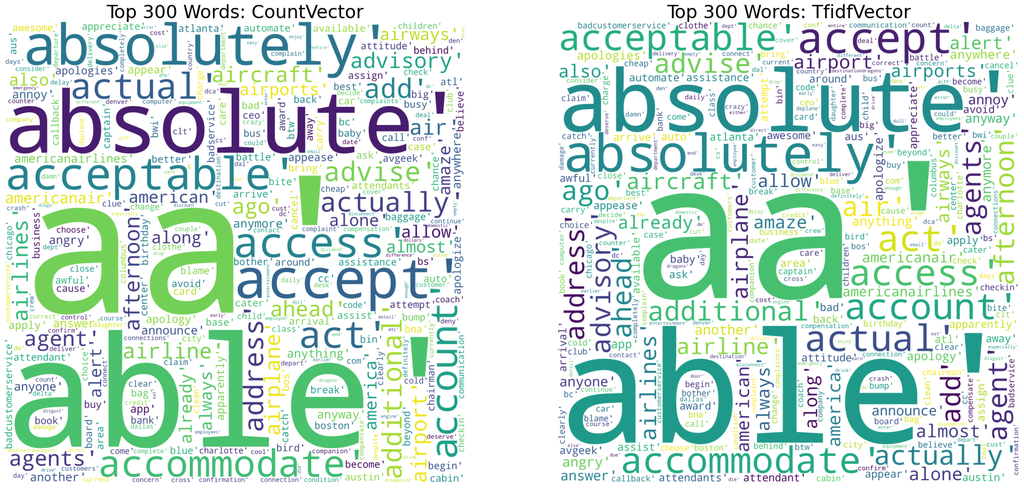

```python
# Visualize the TOP 300 MOST common/frequent Words in the Bag of Words created by CountVector & TfidfVector:

wordcloud_cnt = WordCloud ( stopwords=stp_wrd,
                            width=3000,
                            height=3000,
                            max_words=300,
                            background_color='white'
                          ).generate(str(CountVector.get_feature_names()))

wordcloud_tid = WordCloud ( stopwords=stp_wrd,
                            width=3000,
                            height=3000,
                            max_words=300,
                            background_color='white'
                          ).generate(str(TfidfVector.get_feature_names()))


fig, axes = plt.subplots(nrows=1, ncols=2, figsize=(30, 15))

plt.subplot(1, 2, 1)
plt.imshow(wordcloud_cnt)
plt.title('Top 300 Words: CountVector', fontsize=30)
plt.axis('off')

plt.subplot(1, 2, 2)
plt.imshow(wordcloud_tid)
plt.title('Top 300 Words: TfidfVector', fontsize=30)
plt.axis('off')

# plt.tight_layout()
plt.show();
```

```python
# Prepare Data for Modelling:

# Separate the two columns Text & Sentiments

# 'text   = Predicted / Data
# 'sentim' = Predictor / Label / Target

# Separate df into two datasets : 1. 'X' Message Data (Predicted) and 2. 'Y' Labels / Target (Predictor)
# We already created 'X' dataset in the step above for each of the two Vectorizers: 1. X_CountVect and 2. X_TfidfVect

# Now create one dataset 'Y' for Labels / Target / Predictor:

Y = tdf.sentim

type(Y), Y.shape

print('\n* Labels / Traget Data:')
Y.head()

# Perform One Hot Encoding for the Categorical Labels / Target in dataset 'Y' :

Y_ohe = pd.get_dummies(Y)

# Verify OHE columns, df size, type and column datatypes (should be int/uint8) :
type(Y_ohe), Y_ohe.shape

print('\n* Labels / Traget Data AFTER One Hot Encoding:')
Y_ohe.head()
Y_ohe.info()
```

```
(pandas.core.series.Series, (14452,))
```

```
* Labels / Traget Data:
```

```
0     neutral
1    positive
2     neutral
3    negative
4    negative
Name: sentim, dtype: object
```

```
(pandas.core.frame.DataFrame, (14452, 3))
```

```
* Labels / Traget Data AFTER One Hot Encoding:
```

|  | negative | neutral | positive |
| --- | --- | --- | --- |
| 0 | 0 | 1 | 0 |
| 1 | 0 | 0 | 1 |
| 2 | 0 | 1 | 0 |
| 3 | 1 | 0 | 0 |
| 4 | 1 | 0 | 0 |

```
<class 'pandas.core.frame.DataFrame'>
Int64Index: 14452 entries, 0 to 14639
Data columns (total 3 columns):
 #   Column    Non-Null Count  Dtype
---  ------    --------------  -----
 0   negative  14452 non-null  uint8
 1   neutral   14452 non-null  uint8
 2   positive  14452 non-null  uint8
dtypes: uint8(3)
memory usage: 795.2 KB
```

### Step 5. Modelling and Evaluation:

Fit and Evaluate Models using both types of Vectorizations. (6+6 Marks)

- 5a. CountVectorizer: Fit & Evaluate Model.
- 5b. TfidfVectorizer: Fit & Evaluate Model.

```python
# Step 5a: Fit & Evaluate Model using "Count Vectorized" 'X' dataset:

# Prepare Datasets for Modelling: Split "Count Vectorized" datasets in Train & Test datasets:

X_train, X_test, y_train, y_test = train_test_split(X_CountVect, Y, test_size=0.3, random_state=5)

type(X_train), type(X_test), type(y_train), type(y_test)
X_train.shape, X_test.shape, y_train.shape, y_test.shape
```

```
(numpy.ndarray,
 numpy.ndarray,
 pandas.core.series.Series,
 pandas.core.series.Series)
```

```
((10116, 1000), (4336, 1000), (10116,), (4336,))
```

```python
# Using Random Forest Classifier to build the Multi Class (3 Classes) Classification Model to Classify the Airline Customer Reviews:
# Using "Count Vectorized" 'X' Datasets for Train & Test datasets:

forest = RandomForestClassifier(n_estimators=50, max_depth=25, random_state=3, n_jobs=5)  # criterion='gini',
forest = forest.fit(X_train, y_train)

# Predict the result for Test Data using the Model built above.
result = forest.predict(X_test)

print(*'\n*Metrics For "Count Vectorized" Datasets:')
print('\n * Model & Params:', forest)
print('\n * Test  Accuracy:', forest.score(X_test, y_test))
print('\n * Train Accuracy:', forest.score(X_train, y_train))
print('\n * Cross Validation Score:', np.mean(cross_val_score(forest, X_CountVect, Y, cv=21)))
print('\n * Classification Report: \n\n', classification_report(y_test, result))

# Plot Confusion Matirx to visualize the distribution of the prediction among all the classes.

cm_CountV = confusion_matrix(y_test, result)

print('\n* Confusion Matrix:\n')
print(cm_CountV)
```

```
 * M e t r i c s   F o r   " C o u n t   V e c t o r i z e d "   D a t a s e t s :

 * Model & Params: RandomForestClassifier(max_depth=25, n_estimators=50, n_jobs=5, random_state=3)

 * Test  Accuracy: 0.7211715867158671

 * Train Accuracy: 0.7709568999604587

 * Cross Validation Score: 0.7050248365792464

 * Classification Report:

               precision    recall  f1-score   support

    negative       0.71      0.98      0.83      2726
     neutral       0.72      0.13      0.22       885
    positive       0.79      0.47      0.59       725

    accuracy                           0.72      4336
   macro avg       0.74      0.53      0.54      4336
weighted avg       0.73      0.72      0.66      4336


* Confusion Matrix:

[[2672   17   37]
 [ 718  114   53]
 [ 357   27  341]]
```

```python
# Step 5b: Fit & Evaluate Model using "Tf.Idf Vectorized" 'X' dataset:

# Prepare Datasets for Modelling: Split "Tf.Idf Vectorized" datasets in Train & Test datasets:

X_train, X_test, y_train, y_test = train_test_split(X_TfidfVect, Y, test_size=0.3, random_state=5)

type(X_train), type(X_test), type(y_train), type(y_test)
X_train.shape, X_test.shape, y_train.shape, y_test.shape
```

```
(numpy.ndarray,
 numpy.ndarray,
 pandas.core.series.Series,
 pandas.core.series.Series)
```

```
((10116, 1000), (4336, 1000), (10116,), (4336,))
```

```python
# Using Random Forest Classifier to build the Multi Class (3 Classes) Classification Model to Classify the Airline Customer Reviews:
# Using "Tf.Idf Vectorized" 'X' Datasets for Train & Test datasets:

forest = RandomForestClassifier(n_estimators=50, max_depth=25, random_state=3, n_jobs=5)  # criterion='gini',
forest = forest.fit(X_train, y_train)

# Predict the result for Test Data using the Model built above.
result = forest.predict(X_test)

print(*'\n*Metrics For "Tf.Idf Vectorized" Datasets:')
print('\n * Model & Params:', forest)
print('\n * Test  Accuracy:', forest.score(X_test, y_test))
print('\n * Train Accuracy:', forest.score(X_train, y_train))
print('\n * Cross Validation Score:', np.mean(cross_val_score(forest, X_TfidfVect, Y, cv=21)))
print('\n * Classification Report: \n\n', classification_report(y_test, result))

# Plot Confusion Matirx to visualize the distribution of the prediction among all the classes.

cm_TfidfV = confusion_matrix(y_test, result)

print('\n* Confusion Matrix:\n')
print(cm_TfidfV)
```

```
 * M e t r i c s   F o r   " T f . I d f   V e c t o r i z e d "   D a t a s e t s :

 * Model & Params: RandomForestClassifier(max_depth=25, n_estimators=50, n_jobs=5, random_state=3)

 * Test  Accuracy: 0.7248616236162362

 * Train Accuracy: 0.7787663107947805

 * Cross Validation Score: 0.707031733441343

 * Classification Report:

               precision    recall  f1-score   support

    negative       0.73      0.97      0.83      2726
     neutral       0.60      0.19      0.29       885
    positive       0.79      0.44      0.56       725

    accuracy                           0.72      4336
   macro avg       0.70      0.53      0.56      4336
weighted avg       0.71      0.72      0.68      4336


* Confusion Matrix:

[[2656   41   29]
 [ 659  169   57]
 [ 333   74  318]]
```

```python
# Backup Code:

! cp "Project 8 DL NLP Airline Sentiment Class.ipynb" "Project 8 DL NLP Airline Sentiment Class 7.ipynb"

! ls -l Project*.ipynb
```

```
-rw-r--r--  1 RiddhiSiddhi  staff   34154 Oct  7 00:25 Project 8 DL NLP Airline Sentiment Class 1.ipynb
-rw-r--r--  1 RiddhiSiddhi  staff   60573 Oct 12 22:51 Project 8 DL NLP Airline Sentiment Class 2.ipynb
-rw-r--r--  1 RiddhiSiddhi  staff   72861 Oct 13 15:10 Project 8 DL NLP Airline Sentiment Class 3.ipynb
-rw-r--r--  1 RiddhiSiddhi  staff   98813 Oct 13 21:23 Project 8 DL NLP Airline Sentiment Class 4.ipynb
-rw-r--r--  1 RiddhiSiddhi  staff  102680 Oct 14 00:02 Project 8 DL NLP Airline Sentiment Class 5.ipynb
-rw-r--r--  1 RiddhiSiddhi  staff  118844 Oct 14 00:29 Project 8 DL NLP Airline Sentiment Class 6.ipynb
-rw-r--r--  1 RiddhiSiddhi  staff  300628 Oct 15 01:40 Project 8 DL NLP Airline Sentiment Class 7.ipynb
-rw-r--r--  1 RiddhiSiddhi  staff  300628 Oct 15 01:40 Project 8 DL NLP Airline Sentiment Class.ipynb
```

### Step 6. Conclusion:

Summarize your understanding of the application of Various Pre-processing and Vectorization and performance of your model on this dataset. (8 Marks)

**Conclusion Summary: Presenting the Following Exhibits:**

⬆ Classification Reports: See Above: Steps 5a & 5b: For each of the Two Random Forest Models based on 1. "Count Vectorized" & 2. "Tf.Idf Vectorized" datasets.

⬇ Confusion Matrices Visual: *See Below:*

⬇ Word Cloud Sentiment Visual: *See Below:*

⬇ Sentiment Count Histogram Visual: *See Below:*

⬇ Understandings & Observations: *See Below:*

⬇ Recommendations: *See Below:*

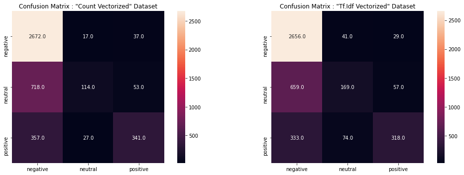

```python
# ⬇ Confusion Metrices Visual: For each of the two RF Models based on 1."Count Vectorized" & 2."Tf.Idf Vectorized" datasets:

fig, axes = plt.subplots(nrows=1, ncols=2, figsize=(15, 5))

# Confusion Metrix for "Count Vectorized" Dataset:

plt.subplot(1, 2, 1)
plt.title('Confusion Matrix : "Count Vectorized" Dataset')
plt.ylabel('True Class')
plt.xlabel('Predicted Class')
sns.heatmap(cm_CountV, annot=True, square=True, fmt=".1f", xticklabels=Y_ohe.columns, yticklabels=Y_ohe.columns)

# Confusion Metrix for "Tf.Idf Vectorized" Dataset:

plt.subplot(1, 2, 2)
plt.title('Confusion Matrix : "Tf.Idf Vectorized" Dataset')
plt.ylabel('True Class')
plt.xlabel('Predicted Class')
sns.heatmap(cm_TfidfV, annot=True, square=True, fmt=".1f", xticklabels=Y_ohe.columns, yticklabels=Y_ohe.columns)

plt.tight_layout()
plt.show();
```

```python
# ⬇ Word Cloud Visual:

# Generate Word Cloud for the Top 300 Most Common Words for each of the Three Sentiments (Classes): 'positive', 'neutral', 'negative' :

# Since we already know from our previous data analysis & observations that these tweets / messages are mostly about...
# ... these Two specific airlines: "VirginAmerica" & "AmericanAir". Hence these two words are most common & predominant.

# So we will ADD these TWO Wrods to a custom Stop Word List for Word Cloud purpose. Because we already know the "subject words".
# Now to get the prominance of other Relevant Words and its Importance which we do NOT know about and which possibly drives the...
# ... Sentiment of the message.


WC_stpw = stp_wrd.copy()  # Get our customized stopword list into a new stopword list

[WC_stpw.append(w) for w in ['virginamerica', 'americanair']]  # Add these two Subject / Dominant words to this new stopword list


# Generate Word Cloud to Display the Top 300 Words separately, for each of the Three Sentiments / Classes (Positive, Neutral, Negative):

wordcloud_pos = WordCloud ( stopwords=WC_stpw,
                            width=3000,
                            height=2500,
                            max_words=300,
                            background_color='green'
                          ).generate(str(tdf.text[tdf.sentim == 'positive']))

wordcloud_neu = WordCloud ( stopwords=WC_stpw,
                            width=3000,
                            height=2500,
                            max_words=300,
                            background_color='yellow'
                          ).generate(str(tdf.text[tdf.sentim == 'neutral']))

wordcloud_neg = WordCloud ( stopwords=WC_stpw,
                            width=3000,
                            height=2500,
                            max_words=300,
                            background_color='red'
                          ).generate(str(tdf.text[tdf.sentim == 'negative']))
```

```
[None, None]
```

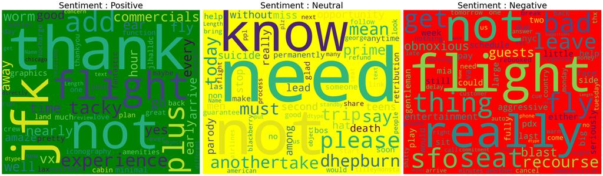

```python
# Display the Top 300 Most Common Words using Word Cloud for each of the Three Sentiments (Classes): 'positive', 'neutral', 'negative' :

fig, axes = plt.subplots(nrows=1, ncols=3, figsize=(30, 10))

plt.subplot(1, 3, 1)
plt.imshow(wordcloud_pos)
plt.title('Sentiment : Positive', fontsize=30)
plt.axis('off')

plt.subplot(1, 3, 2)
plt.imshow(wordcloud_neu)
plt.title('Sentiment : Neutral', fontsize=30)
plt.axis('off')

plt.subplot(1, 3, 3)
plt.imshow(wordcloud_neg)
plt.title('Sentiment : Negative', fontsize=30)
plt.axis('off')

plt.tight_layout()
plt.show();

# ⬇ Below: 300 Most Common / Dominant Words are indicated by the contrast in Fontsize & Color compared to less Common / Dominant words⬇
```

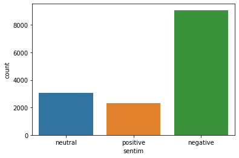

```python
# ⬇ Sentiment Count Histogram Visual:

sns.countplot(tdf.sentim);
```

⬇ Understanding & Observations:

Note: I attempted several way (RFC Parameters) to increase TEST Accuracies but it stayed in 7x% (0.7x) range, even though TRAIN Accuracies had gone up to high 90s% which was a diffrence of 20% point between Train & Test (Highly Overfitting). So I tweeked further to bring Train & Test numbers resonably close to each other. Hence the Train numbers came down to 70s% from 90s% so that its not Highly OverFitted. I also tried AdaBoost & GradientBoost Classifiers with several various Parameter combinations. I have removed the Code & Output from these Trial, Experiments, Attempts so as to reduce the non significant clutter from this Project's Code Notebook.

⬇ Recommendation:

1. Airline personnel should improve their Customer Interaction: A major share of Negative Reviews as about Bad inflight Service, Rudeness with Customers on Ground and issues about Rebooking flights.
2. Flight Delays maybe beyond Airline's control, which is one of the top reasons for Negative Reviews, in which case airline can offer other accomodations and/or perks to Pacify Customers and avoid their -ve reviews.
3. - Airline can stratigize the Neutrals Reviewers (Customers) who are on the fence (borderline) to make them happy so they can give Positive Reviews.
   - Meaning, try to Convert Neutral Customer so they write Positive Reviews, which would be much easier than converting Negative Reviewers to Positive ones.
   - This can help reputation "Damage Control" as short term solution, while the airline works on the issues of Negative Reviewers as outlined in points 1 & 2 above.
   - As derived earlier during EDA and as depicted by Sentiment Histogram above in this Section, this how the number looks like:
   - Positive = 2,363 (16%) *Neutral = 3,099 (21%)* Negative = 9,178 (62%) = Total Reviews = 14,640 (100%)
   - If All or Most Neutrals are Converted to Positives then total Positives would be 5,462 (37%) (Up by 21% to 37% !!!)

```python
# Backup Code: Just After Confusion Matrix Visual Above:

! cp "Project 8 DL NLP Airline Sentiment Class.ipynb" "Project 8 DL NLP Airline Sentiment Class 8.ipynb"

! ls -l Project*.ipynb
```

[output not shown]

```python
# Backup Code: After above notes till this point:

! cp "Project 8 DL NLP Airline Sentiment Class.ipynb" "Project 8 DL NLP Airline Sentiment Class 9.ipynb"

! ls -l Project*.ipynb
```

```
-rw-r--r--  1 RiddhiSiddhi  staff    34154 Oct  7 00:25 Project 8 DL NLP Airline Sentiment Class 1.ipynb
-rw-r--r--  1 RiddhiSiddhi  staff    60573 Oct 12 22:51 Project 8 DL NLP Airline Sentiment Class 2.ipynb
-rw-r--r--  1 RiddhiSiddhi  staff    72861 Oct 13 15:10 Project 8 DL NLP Airline Sentiment Class 3.ipynb
-rw-r--r--  1 RiddhiSiddhi  staff    98813 Oct 13 21:23 Project 8 DL NLP Airline Sentiment Class 4.ipynb
-rw-r--r--  1 RiddhiSiddhi  staff   102680 Oct 14 00:02 Project 8 DL NLP Airline Sentiment Class 5.ipynb
-rw-r--r--  1 RiddhiSiddhi  staff   118844 Oct 14 00:29 Project 8 DL NLP Airline Sentiment Class 6.ipynb
-rw-r--r--  1 RiddhiSiddhi  staff   300628 Oct 15 01:40 Project 8 DL NLP Airline Sentiment Class 7.ipynb
-rw-r--r--  1 RiddhiSiddhi  staff   346130 Oct 15 02:14 Project 8 DL NLP Airline Sentiment Class 8.ipynb
-rw-r--r--  1 RiddhiSiddhi  staff  2621295 Oct 16 08:08 Project 8 DL NLP Airline Sentiment Class 9.ipynb
-rw-r--r--  1 RiddhiSiddhi  staff  2621295 Oct 16 08:08 Project 8 DL NLP Airline Sentiment Class.ipynb
```